# Solving Ordinary Differential Equations (ODEs) in R

Mark Wilber and Cherie Briggs

August 6, 2017

**Packages you will need for this lesson**

1. `deSolve`
2. `rootSolve`
3. `ggplot2`

```r
library(deSolve)
library(rootSolve)
library(ggplot2)
```

**Learning Goals**

1. Learn how to obtain numerical solutions to ODEs using R
2. Learn how to calculate the conditions for pathogen invasion, and $R_0$
3. Learn how to caculate equilibrium values analytically, numerically, and through simulations

## Numerical solutions to continuous-time systems, Ordinary Differential Equations (ODEs)

At the end of the last section, we found that we could write our own program to approximate the solutions to ordinary differential equations using Euler’s method. The Euler method is one of a number of numerical methods for solving ODEs, and it is the simplest method. A number of other methods have been devised to improve the speed and/or accuracy of numerical solultions to ODEs. Many of these methods use “adaptive time steps”, that take very small time steps when the state variables are changing rapidly and larger time steps when the state variables are changing slowly. R has a number of built-in functions for solving systems of ODEs using many of these methods. In this exercise, we will use the `lsoda` function from the R package, `deSolve`, to do this (make sure you have the package `deSolve` installed and loaded).

If you look up `lsoda` in the manual it says that it solves *“initial value problems for stiff or non-stiff systems of first-order ordinary differential equations (ODEs)”*.

What does that mean??

*“initial value problem”* means that you are supplying the state of the system at some point in time (e.g. the initial conditions at time t=0).

*“stiff or non-stiff systems”* is apparently harder to define. The Wikipedia definition of a “stiff equation” is: “In mathematics, a stiff equation is a differential equation for which certain numerical methods for solving the equation are numerically unstable, unless the step size is taken to be extremely small. It has proven difficult to formulate a precise definition of stiffness, but the main idea is that the equation includes some terms that can lead to rapid variation in the solution.” `lsoda` decides whether or not your system of equations is “stiff”, and switches automatically between stiff and non-stiff methods, so you don’t have to worry about it.

*“systems of first-order ODEs”* means that we have any number of equations that include only first derivatives, e.g. $\frac{d S}{dt} = ...$

There are two steps involved in obtaining numerical solutions to differential equations:

- **Step 1.** Write a function `func` (this function can be named anything that you want), that calculates the right hand side of the differential equations. `func` must take as its first three arguments the current time (`t`), the current values of the state variables (`y`), and a vector containing the parameter values. It must also return a list (using `list(item1, item2, item3)`) whose elements the right hand sides of the ODEs.
- **Step 2.** Use `lsoda` to solve the system of ODEs.

## Simulating a continuous-time SIR model in R

Let’s use `lsoda` to solve the simple continuous-time SIR model:

This model has three **state variables**:

- $S$: the density of susceptible (uninfected) individuals
- $I$: the density of infected individuals
- $R$: the density of recovered individuals, who are now resistant to further infection

And, it has 2 **parameters**:

- $\beta$: Transmission parameter (units = infecteds$^{-1}$time$^{-1}$)
- $\gamma$: Recovery rate (units = time$^{-1}$)

The system of first-order ODEs that describes the rate of change of the 3 state variables are:
$$\begin{align}
\frac{d S}{dt} &= -\beta I S \\
\frac{d I}{dt} &= \beta I S - \gamma I \\
\frac{d R}{dt} &= \gamma I
\end{align}$$

- **Step 1.** The first step is to write a function that takes as input the current time $t$, a vector that contains the current values of the 3 state variables $x$, and a vector that contains the parameter values $params$, and returns a list containing the right hand side of the 3 ordinary differential equations (i.e. it returns the rate of change of the 3 state variables.)

```r
SIR.model <- function (t, x, params) {
  S = x[1]
  I = x[2]
  R = x[3]
  beta = params[1]
  gamma = params[2]

  dSdt = -beta*S*I
  dIdt = beta*S*I - gamma*I
  dRdt = gamma*I

 return(list(c(dSdt,dIdt,dRdt)))
}
```

The first part of this function is really just to make it readable to us. The first 3 lines specify that within this function we are going to define $S$ as the first term in the vector of state variables, $I$ as the second term, and $R$ as the third term. Similarly, the next 2 lines specify that within this function we are going to define $\beta$ as the first term in the vector of parameters, and $\gamma$ as the second term. We could have written the ODEs just in terms of $x[1]$, $params[1]$, etc, but that would make the code a lot more difficult to read!

The second part of our `SIR.model` function defines the ordinary differential equations that describe how the state variables change through time, and packs the results into a “list” to export the results.

The `lsoda` function will call our user-defined `SIR.model` function over and over again in order to calculate the numerical solution to this system of ODEs.

Although we don’t usually have a reason to do this, we could call the `SIR.model` function by first specifying a value for time, a vector for the current value of the state variables, and a vector with the values of the parameters:

```r
current_time=5
current_state=c(1,2,3)
my_parameters=c(0.1,2)
SIR.model(current_time,current_state,my_parameters)
```

```
[[1]]
[1] -0.2 -3.8  4.0
```

It should return a list that gives the rate of change of the 3 state variables.  
For these made-up conditions, $S$ is decreasing, $I$ is decreasing, and $R$ is increasing.

- **Step 2.** The second step is to use `lsoda` to solve the system of ODEs.

In order to call `lsoda`, we will use the code:

`lsoda(initial_values, times, function, parameters)`

The main arguments for `lsoda` are a vector with the starting values of the state variables (`initial_values`), a vector with the times at which you want to compute the values of the variables you are interested in (`times`), the derivative function (`function`), and a vector with the model parameters (`parameters`). (There are a number of additional optional arguments for `lsoda` that do things like set the maximum step size for the numerical algorithm. We won’t worry about these for how.)

For the SIR model, `function` will be the `SIR.model` function that we just wrote.

`initial_values` is a vector that gives the starting values of the state variables in the model. They should be in the same order as in the user-defined function (i.e. for our case, in the same order as in the `SIR.model` function). Let’s use the same initial values that we used in the last exercise:

```r
S0 = 99 # Initial number of susceptibles
I0 = 1 # Initial number of infecteds
R0 = 0 # Initial number of recovered
initial_values = c(S0,I0,R0)
```

`parameters` is a vector that gives the values for the model parameters. Again, they should be in the same order as in the user-defined function. Let’s use the same parameter values that we used in the last exercise:

```r
beta = 0.1 # per host per week
gamma = 1 # per week
parameters = c(beta,gamma)
```

times is a vector that lists all of the times for which you want `lsoda` to output the solution to the ODEs. Let’s simulate the model for 5 weeks, outputing the data every 0.01 week.

Note: we do not need to specify the time step in `lsoda`. This method uses an adaptive time step, so it is actually using a time step that is changing through time. This part of the code is just specifying at what intervals you would like to see the results.

```r
times = seq(0, 5, by=0.01)
```

We now have all of the bits that `lsoda` needs to obtain a numerical solution to the ODEs. We can have it save the results in the matrix `results`:

```r
results = lsoda(initial_values, times, SIR.model, parameters)
# Naming columns for easy identification
colnames(results) = c("time", "S", "I","R")
```

R has simulated our model for 5 weeks and stored the values in the matrix `results`.

The output looks like this. The column order is: 1) time, 2) state variable 1 ($S$), 3) state variable 2 ($I$), and 4) state variable 3 ($R$).

```r
head(results)
```

```
     time        S        I          R
[1,] 0.00 99.00000 1.000000 0.00000000
[2,] 0.01 98.89652 1.093026 0.01045847
[3,] 0.02 98.78354 1.194574 0.02188893
[4,] 0.03 98.66021 1.305405 0.03438088
[5,] 0.04 98.52564 1.426334 0.04803084
[6,] 0.05 98.37881 1.558246 0.06294416
```

Now you can plot the results, using either ggplot2:

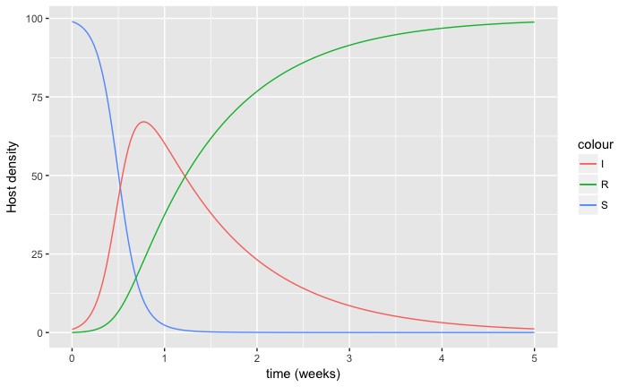

```r
# Plotting in ggplot
ggplot(data=NULL, aes(x=results[, "time"], y=results[, "S"], color="S")) + geom_line() +
    geom_line(data=NULL, aes(x=results[, "time"], y=results[, "I"], color="I")) +
    geom_line(data=NULL, aes(x=results[, "time"], y=results[, "R"], color="R")) +
  xlab("time (weeks)") + ylab("Host density")
```

or R’s base plot:

```r
# Plotting in base plot
plot(results[, "time"], results[, "S"], type="l", col="blue",
     xlab="time (weeks)", ylab="Host density", ylim=c(0, S0 + 1))
lines(results[, "time"], results[, "I"], type="l", col="red")
```

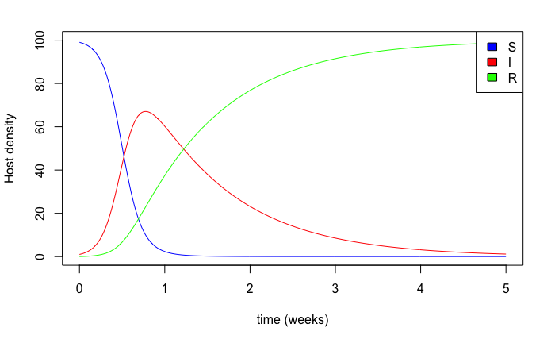

```r
lines(results[, "time"], results[, "R"], type="l", col="green")
legend("topright", legend=c("S", "I", "R"), fill=c("blue", "red", "green"))
```

It is often easier to use the output from the ODE solver if you convert it to an R dataframe and label the columns. You can do this by changing these two lines of code:

```r
# OPTIONAL CODE TO STORE OUTPUT AS A DATAFRAME
initial_values = c(S=S0,I=I0,R=R0)
results = as.data.frame(lsoda(initial_values, times, SIR.model, parameters))
```

## Calculating $R_0$

Consider the initial arrival of the pathogen into an entirely susceptible population (i.e. when all individuals are in the susceptible class, $S(0) = N$). What factors will determine whether an epidemic will occur, or if the pathogen will fail to invade?

The pathogen can invade a fully susceptible population when $\frac{dI}{dt} > 0$.

For the SIR model with density-dependent transmission, the equation for the rate of change of the density of infected can be re-written as: $\frac{d I}{dt} = I(\beta S - \gamma)$

Thus, for the SIR model with density-dependent transmission, $\frac{\gamma}{\beta}$ is the **threshold density for pathogen invasion**. If the initial density of susceptible hosts is greater than $\frac{\gamma}{\beta}$, then the pathogen can invade, and if the initial density of susceptible hosts is less than $\frac{\gamma}{\beta}$ then the infection dies out.

This can be rearranged to show that the disease can invade a fully susceptible population only when (here we’re assuming that during the initial stages of the pathogen invasion, all individuals are in the suceptible class, so the total density of hosts ($N$) is equal to the density of susceptible hosts ($S$):
$$\begin{align}
R_0 = \frac{\beta N}{\gamma} > 1
\end{align}$$
$R_0$ is called the **basic reproductive ratio**. It is defined as the *average number of secondary cases arising from an average primary case in an entirely susceptible population*. $R_0$ can be calculated as the rate at which new cases are produced by an infectious individual ($\beta N$) multiplied by the average duration of the infectious period ($1/\gamma$).

### Exercise 1: Explore the effects of changing the initial conditions.

> 1. Prove to yourself that $\frac{\gamma}{\beta}$ is the threshold population density for pathogen invasion. Try varying the initial density of the susceptible population. What is the lowest initial density of susceptibles for which the infected population can have a positive growth rate?
> 2. In the cases where the pathogen can invade (i.e. for $S(0) > \frac{\gamma}{\beta}$), do all individuals in the population eventually get infected? (You’ll need to extend the maximum time for the simulations to see what happens in the long term.)

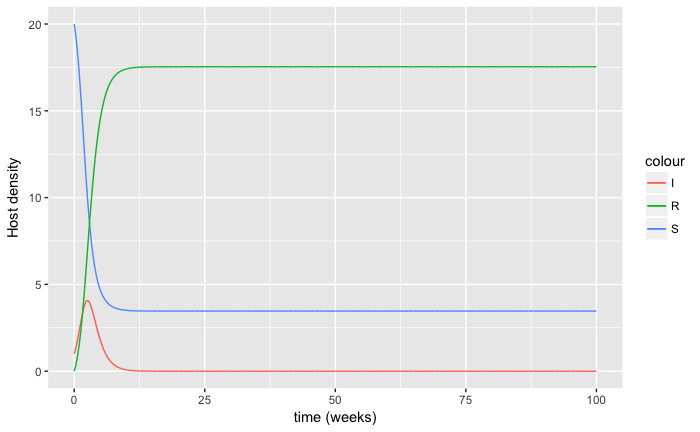

```r
#HIDE ME IF YOU DON'T WANT TO SEE THE ANSWER
# ALL OF THE CODE FOR THE DENSITY-DEPENDENT MODEL
SIR.model <- function (t, x, params) {
  S = x[1]
  I = x[2]
  R = x[3]
  beta = params[1]
  gamma = params[2]

  dSdt = -beta*S*I
  dIdt = beta*S*I - gamma*I
  dRdt = gamma*I

 return(list(c(dSdt,dIdt,dRdt)))
}
S0 = 20 # Initial number of susceptibles
I0 = 1 # Initial number of infecteds
R0 = 0 # Initial number of recovered
initial_values = c(S=S0,I=I0,R=R0)
beta = 0.1 # per host per week
gamma = 1 # per week
parameters = c(beta,gamma)
times = seq(0, 100, by=0.01)
results = lsoda(initial_values, times, SIR.model, parameters)
colnames(results) = c("time", "S", "I","R")
# Plotting in ggplot
ggplot(data=NULL, aes(x=results[, "time"], y=results[, "S"], color="S")) + geom_line() +
    geom_line(data=NULL, aes(x=results[, "time"], y=results[, "I"], color="I")) +
    geom_line(data=NULL, aes(x=results[, "time"], y=results[, "R"], color="R")) +
  xlab("time (weeks)") + ylab("Host density")
```

A few things to note are:

- In this **deterministic** version of the model, there are always some susceptible hosts in the population that escape infection (i.e. $S$ is never driven completely to zero, although $S$ can get really, really small).
- The larger the initial density of susceptible hosts, the greater the fraction of hosts that become infected.
- The chain of transmission eventually breaks due to the decline in infectives, not due to the complete lack of susceptibles. **“epidemic burnout”**.

We can illustrate some of these properties through simulation, using a `for` loop.

```r
Tend = 100 # end time for simulations
times = seq(0, Tend, by=1)
beta = 0.1 # per host per week
gamma = 1 # per week
parameters = c(beta,gamma)
# start all simulations with 1 infected and 0 recoverds
I0 = 1 # Initial number of infecteds
R0 = 0 # Initial number of recovereds
S0_all<-seq(1,50,0.1)       # use a sequence of values for S0
# set up a vector to store host equilibrium values
S_longterm = rep(0,length(S0_all))
I_longterm = rep(0,length(S0_all))
R_longterm = rep(0,length(S0_all))

for (i in 1:length(S0_all)) {  # loop through all values of S0

    #specify the initial values of state-variables
    initial_values = c(S0_all[i],I0,R0)
    results = lsoda(initial_values, times, SIR.model, parameters)
    #save only the final values of the state variable
    S_longterm[i] = results[Tend+1,2]
    I_longterm[i] = results[Tend+1,3]
    R_longterm[i] = results[Tend+1,4]
}
#plot the final vs. initial number of susceptibles
plot(S0_all, S_longterm, type = "l", xlab="initial density of Susceptibles, S(0)", ylab="density of Susceptibles remaining")
lines(S0_all, S0_all, type="l", lty=2, col="blue")
```

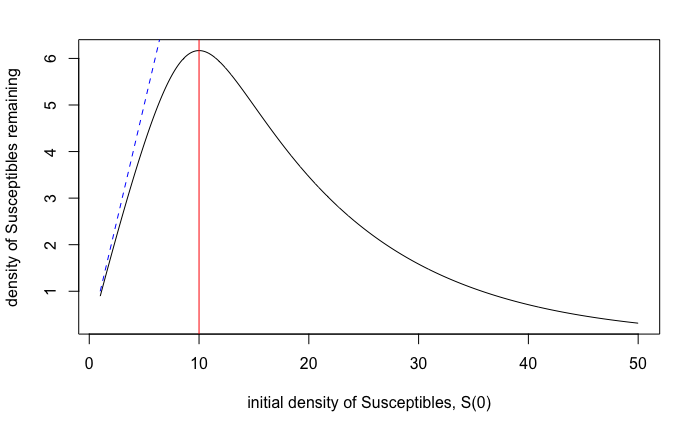

```r
abline(v=gamma/beta,col="red")
```

The blue line has a slope of 1, that is, where the final density of Susceptibles equals the initial density of susceptibles.  
The red line is the threshold density of Susceptibles for pathogen invasion.

We could also plot the fraction of Susceptibles that survive as a function of the initial density of Susceptibles:

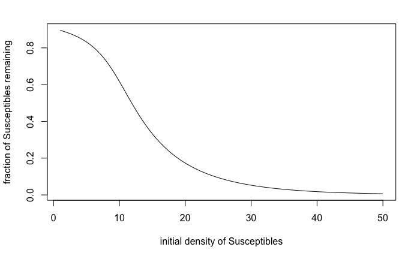

```r
frac_susceptible = S_longterm/S0_all
plot(S0_all, frac_susceptible, type = "l", xlab="initial density of Susceptibles", ylab="fraction of Susceptibles remaining")
```

### Exercise 2: Explore the effects of changing the transmission function

> In the version of the model above, we assumed that the transmission rate is density dependent. That is, the force of infection is proportional to the density of infected individuals in the population, $\beta I$, and the rate loss of susceptible individuals is $\beta I S$.

> We could instead assume that the transmission rate is frequency dependent. For frequency dependent transmission, the force of infection is proportional to the fraction of infected individuals, $\frac{\beta I}{N}$, where $N = S + I + R$ is the total population size, and the rate of loss of susceptible individuals is $\frac{\beta I S}{N}$.

> Code up the model with frequency-dependent transmission. Now try varying the size of the susceptible population. In this case, is there a threshold population size below which the infected population cannot have a positive growth rate?

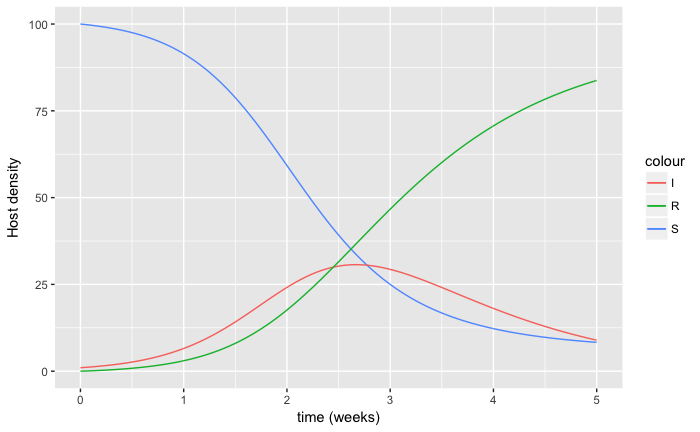

```r
# HIDE ME IF YOU DON'T WANT TO SEE THE ANSWER
# ALL OF THE CODE FOR THE FREQUENCY-DEPENDENT MODEL
#new function with frequency-dependent transmission rate
SIR.freqdep.model <- function (t, x, params) {
  S = x[1]
  I = x[2]
  R = x[3]
  beta = params[1]
  gamma = params[2]

  N=S+I+R
  dSdt = -beta*S*I/N
  dIdt = beta*S*I/N - gamma*I
  dRdt = gamma*I

 return(list(c(dSdt,dIdt,dRdt)))
}
S0 = 100 # Initial number of susceptibles
I0 = 1 # Initial number of infecteds
R0 = 0 # Initial number of recovered
initial_values = c(S=S0,I=I0,R=R0)
#
beta =  3 # per week
gamma = 1 # per week
parameters = c(beta,gamma)
#
times = seq(0, 5, by=0.01)
#
results.freqdep = as.data.frame(lsoda(initial_values, times, SIR.freqdep.model, parameters))
colnames(results) = c("time", "S", "I","R")
#
# Plotting in ggplot
ggplot(data=NULL, aes(x=results.freqdep[, "time"], y=results.freqdep[, "S"], color="S")) + geom_line() +
    geom_line(data=NULL, aes(x=results.freqdep[, "time"], y=results.freqdep[, "I"], color="I")) +
    geom_line(data=NULL, aes(x=results.freqdep[, "time"], y=results.freqdep[, "R"], color="R")) +
  xlab("time (weeks)") + ylab("Host density")
```

If you kept the values for the parameters the same as in the density-dependent model, you will find that the pathogen always fails to invade. Why is that?

Remember, the pathogen can invade a fully susceptible population when $\frac{dI}{dt} > 0$.

For the SIR model with frequeny-dependent transmission, the equation for the rate of change of the density of infected can be re-written as: $\frac{d I}{dt} = I(\frac{\beta S}{N} - \gamma)$

When the host population is fully susceptible, $S = N$ so the pathogen can invade only when $\beta > \gamma$. For the frequency-dependent model, the criterion for invasion does not depend on the density of susceptible hosts. That is, there is no threshold density for pathogen invasion.

But, in oder for the pathogen to have a positive growth rate, we need to increase the value of the transmission parameter, $\beta$. Note, that the **units** of the transmission parameter are different between the density-dependent and frequency-dependent model.

In the density-dependent model, $\beta$ has units of $\frac{1}{host*time}$

In the frequency-dependent model, $\beta$ has units of $\frac{1}{time}$

Once again, this can be rearranged to show that the disease can invade a fully susceptible population only when:
$$\begin{align}
R_0 = \frac{\beta}{\gamma} > 1
\end{align}$$
How does changing the initial density of susceptible hosts affect the number or fraction of hosts that become infected during the outbreak?
We can use our code with the `for` loop once again to find this out.

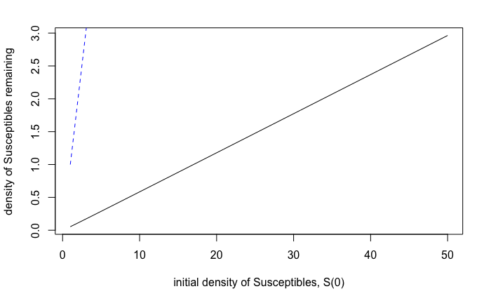

```r
Tend = 500 # end time for simulations
times = seq(0, Tend, by=1)
beta = 3 # per week
gamma = 1 # per week
parameters = c(beta,gamma)
# start all simulations with 1 infected and 0 recoverds
I0 = 1 # Initial number of infecteds
R0 = 0 # Initial number of recovereds
S0_all = seq(1,50,0.1)      # use a sequence of values for S0
# set up a vector to store host equilibrium values
S_longterm.freqdep = rep(0,length(S0_all))
I_longterm.freqdep = rep(0,length(S0_all))
R_longterm.freqdep = rep(0,length(S0_all))

for (i in 1:length(S0_all)) {  # loop through all values of S0

    #specify the initial values of state-variables
    initial_values = c(S0_all[i],I0,R0)
    results.freqdep = lsoda(initial_values, times, SIR.freqdep.model, parameters)
    #save only the final values of the state variable
    S_longterm.freqdep[i] = results.freqdep[Tend+1,2]
    I_longterm.freqdep[i] = results.freqdep[Tend+1,3]
    R_longterm.freqdep[i] = results.freqdep[Tend+1,4]
}
#plot the final vs. initial number of susceptibles
plot(S0_all, S_longterm.freqdep, type = "l", xlab="initial density of Susceptibles, S(0)", ylab="density of Susceptibles remaining")
lines(S0_all, S0_all, type="l", lty=2, col="blue")
```

We could also plot the fraction of Susceptibles that survive as a function of the initial density of Susceptibles:

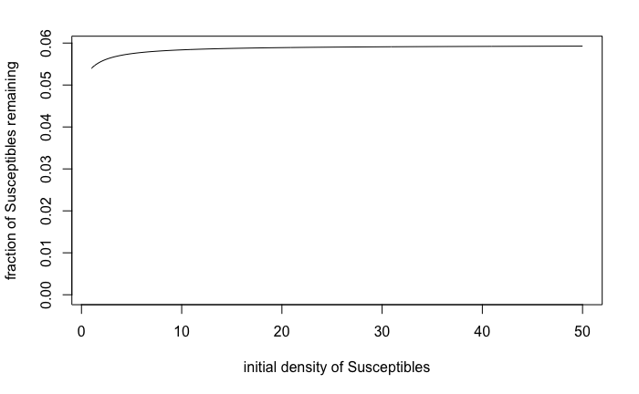

```r
frac_susceptible = S_longterm.freqdep/S0_all
plot(S0_all, frac_susceptible, type = "l", xlab="initial density of Susceptibles", ylab="fraction of Susceptibles remaining", ylim = c(0,max(frac_susceptible)))
```

## Exploring long-term equilibrium dynamics, using a continuous-time SIR model with host demography

The SIR model that we have used so far simulates a short-term epidemic in a host population. It does not include births or deaths of hosts. Let’s add these to the model in order to explore the long-term host/pathogen dynamics.

Let’s assume that the “background” mortality rate for hosts in all classes is $\mu$, and that infected individuals experience an additional disease-induced mortality rate $\alpha$.

And for simplicity, let’s assume that there is a constant input of new susceptibles into the population, at rate $\phi$.

For now, let’s assume a density-dependent form of the transmission function.

Our new model is:
$$\begin{align}
\frac{d S}{dt} &= \phi -\beta I S - \mu S \\
\frac{d I}{dt} &= \beta I S - \gamma I - (\mu + \alpha) I \\
\frac{d R}{dt} &= \gamma I - \mu R
\end{align}$$
For this model, the disease-free equilibrium is $S^* = \frac{\phi}{\mu}$, with $I^* = 0$, and $R^* = 0$.

### Exercise 3: Explore the dynamics of the SIR model with host demography.

> 1. **Code up the SIR model with host demography.** First write the new function describing this model. Then use `lsoda` to simulate the model numerically. You will want to run the model for a long enough time period to see the long-term dynamics.
> 2. Try running the model starting at the disease-free equilibrium, $S^* = \frac{\phi}{\mu}$, with $I^* = 0$, and $R^* = 0$. What happens?
> 3. Now introduce a low density of infecteds. What happens?
> 4. Try varying the rate of input of new susceptibles, $\phi$. How does it affect the ability of the pathogen to invade?

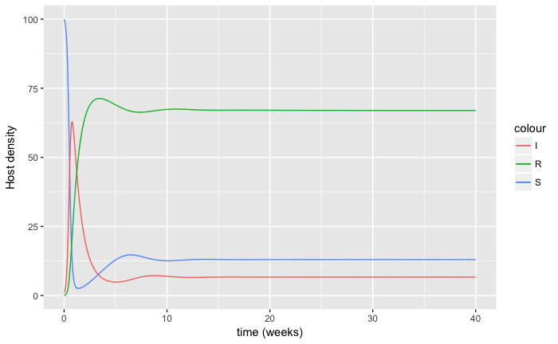

```r
# HIDE ME IF YOU DON'T WANT TO SEE THE ANSWER
# SIR model with host demography, and density-dependent transmission
SIR.demog.model <- function (t, x, params) {
  S = x[1]
  I = x[2]
  R = x[3]
  beta = params[1]
  gamma = params[2]
  phi = params[3]
  mu = params[4]
  alpha = params[5]

  N=S+I+R
  dSdt = phi-beta*S*I - mu*S
  dIdt = beta*S*I - gamma*I - (mu+alpha)*I
  dRdt = gamma*I - mu*R

 return(list(c(dSdt,dIdt,dRdt)))
}
beta = 0.1 # per host per week
gamma = 1 # per week
phi = 10
mu = 0.1
alpha = 0.2
S0 = phi/mu # Initial density of susceptibles
I0 = 1 # Initial density of infecteds
R0 = 0 # Initial density of recovered
initial_values = c(S=S0,I=I0,R=R0)
parameters = c(beta,gamma,phi,mu,alpha)
times = seq(0, 40, by=0.01)
results.demog = lsoda(initial_values, times, SIR.demog.model, parameters)
# Plotting in ggplot
ggplot(data=NULL, aes(x=results.demog[, "time"], y=results.demog[, "S"], color="S")) + geom_line() +
    geom_line(data=NULL, aes(x=results.demog[, "time"], y=results.demog[, "I"], color="I")) +
    geom_line(data=NULL, aes(x=results.demog[, "time"], y=results.demog[, "R"], color="R")) +
  xlab("time (weeks)") + ylab("Host density")
```

Depending on the rate of input of new susceptibles $\phi$, there will either be a short disease outbreak, or the system will reach an equilibrium with the pathogen present.

### Calculating $R_0$ for the SIR model with host demography

For the SIR model with host demography, the equation for the rate of change of the density of infected can be re-written as: $\frac{d I}{dt} = I(\beta S - \gamma - \mu - \alpha)$.

Thus, the pathogen can invade a fully susceptible population when $S > \frac{\gamma + \mu + \alpha}{\beta}$

### Determining equilibrium solutions, analytically and numerically

If the pathogen can invade, how do we calculate the equilibrium density with the pathogen present? In this exercise, we will explore methods for determining the equilibrium values of the state variables for models consisting of systems of ordinary differential equation.

An **equilibrium** is a constant solution to a set of differential equations. The equilibrium is the value of the state variables in a model for which the rates of change of the state variables are equal to zero.

**In this exercise, we will explore 3 different methods for determining the equilibrium solution to models.**

1. **Simulation**. For specified values of parameters and initial conditions of the state variable, we can simply run the model for a long time period and see if the state variables level off at an equilibrium value.
- *Advantages:* It’s easy. We already have the tools to do this. We can attempt this with any model.
- *Disadvantages:* (a) It requires specifying the values of all parameters and the initial values of all state variables. (b) The trajectories of the state variables will level off at an equilibrium value only if the equilibrium is stable. If the equilibrium is unstable, then the long-term solution of the system of differential equations may be exponential growth (or decline), population cycles, or a chaotic trajectory, rather than a point equilibrium. (c) Even if the equilibrium is stable, it can take a long time for population trajectory to settle at the equilibrium (e.g. see Hastings, A. 2004. Transients: the key to long-term ecological understanding? TREE 19(1):39-45). (d) Some models can have multiple equilibria, such that for a particular set of parameters the model may settle at different equilibrium values depending on the initial values of the state variables chosen. This means that simulations may need to be started at a range of values of the state variables to ensure that there is only one equilibrium.
2. **Analytically.** For some models, we can write down an analytical expression for $N^*$ by using algebra to solve the equation $f(N^*) = 0$ for $N^*$.
- *Advantages:* We don’t need to specify specific values for the parameters, so we can interpret the effects of changing the values of parameters for all of parameter space.
- *Disadvantages:* Sometimes it’s not possible to obtain an explicit, closed-form, solutions to the equation $f(N^*) = 0$. (Transcendental equations; e.g. $f(N^*)=exp(-N^*) - N*$. Also, sometimes solving for the equilibrium solutions can require some really messy algebra.
3. **Numerically.** We can use one of a number of numerical methods to numerically find the solution N* to the equation $f(N^*) = 0$ for specified values of parameters.
- *Advantages:* We can numerically find solutions to equations for which it is not possible to find explicit, closed-form, solutions (e.g. transcendental equations). We can numerically find the equilibrium values, even if the equilibrium is not stable.
- *Disadvantages:* This approach requires specifying the values of all parameters. It also requires making an initial guess at the equilibrium solution. If the guess is too far from the actual equilibrium, then the numerical methods may fail to converge on the solution. If the model has multiple equilibria, then it may not find all equilibrium values (or may require investigating many starting guesses to find all equilibrium values).

### Calculating the equilibrium of the SIR model with host demography

Let’s try using all three of these methods to calculate the long-term equilibrium densities of the SIR model with host demography.

1. **Simulation**. We have already shown that we can calculate the equilibrium of this model through simulation. for example, if we use these parameters:

```r
beta = 0.1 # per infecteds per week
gamma = 1 # per week
phi = 10
mu = 0.1
alpha = 0.2
```

We can look at the final state of the system:

```r
tail(results.demog,1)
```

```
        time  S       I        R
[4001,]   40 13 6.69231 66.93834
```

From looking at the simulation, it appears that 40 weeks is long enough for the system to settle down to its equilibrium, with: $S^* = 13$, $I^* = 6.69231$, and $R^* = 66.93834$.

2. **Analytically.** To calculate the equilibrium solution for the SIR model we set $S = S*$, $I = I*$, and *R = R*$, and set the right hand side of all 3 differential equations equal to zero. We then find the solution to the 3 simultaneous equations. This just requires a bit of algebra.
   $$\begin{align}
   S^* = \frac{\gamma + \mu + \alpha}{\beta}\\
   I^* = \frac{\phi - \mu S^*}{\beta S^*}\\
   R^* = \frac{\gamma I}{\mu}
   \end{align}$$

Inspecting these equations, we can see that depending on the values of the parameters, it is possible for the equilibrium density of infected to be negative (which really doesn’t make sense). We can see that the pathogen can persist, with $I^* > 0$ only if $\phi > \mu S^*$.

It’s useful to have an analytical expression for the equilibrium, because we can see how each of the parameters affects the equilibrium, without having to specify the exact values of all of the parameters.

**Note:** For this model, I purposely used a very simple form of host fecundity, because it makes it easy to solve for equilibrium. You can try different versions of host fecundity to show that things become really complicated. For example, try replacing the constant input of new susceptibles, $\phi$, with something like a Ricker birth term: $r N \exp(-c N)$, where $N = S + I + R$, and see if it’s possible to obtain an analytical expression for the equilibrium.

3. **Numerically.** This approach isn’t really necessary for this simple model, for which we already have an analytical expression for $S^∗$, $I^*$, and $R^*$, but we’ll illustrate the approach with this model. We will make use of the package `rootSolve` in R to do this. `rootSolve` is a nonlinear root-finding package that has a number of useful functions (**“root”** is a more formal way to say the “solution” to the equation). If you have a single equation, you can use the `uniroot.all` function, which solves for all roots of one (nonlinear) equation. For this exercise, we will use the `multiroot` function, which solves for n roots of n (nonlinear) equations.

To do this exercise, make sure you have installed and loaded the R package `rootSolve`.

```r
library(rootSolve)
```

Because we now have three equations that we want to solve simultaneously, we will use the R function `multiroot` from the package rootSolve. Given a vector of n variables, and a set of n (nonlinear) equations in these variables, multiroot estimates the root of the equations, i.e. the variable values where all function values = 0. `multiroot` uses the **Newton-Raphson root-solving method**, which you can look up if you’re interested.

The syntax for calling multiroot is:

multiroot(f, start, …)

where `f` is a the function for which the root is sought; it must return a **vector** with as many values as the length of start. The function is called either as f(x, …) if parms = NULL or as f(x, parms, …) if parms is not NULL. `start` is a vector containing initial guesses for the unknown x; if start has a name attribute, the names will be used to label the output vector. `...` specifies additional arguments that you don’t need to include yet, but you may want to look into if you end up using this method a lot.

Here is the R code for our SIR example: This function returns a vector with the right hand sides of the ODEs

```r
# unfortunately, multiroot wants a function that returns a vector, rather than a list
# so, we have to slightly re-write the function
RHS_SIR <- function(x, parms) {
  S = x[1]
  I = x[2]
  R = x[3]
  beta = parms[1]
  gamma = parms[2]
  phi = parms[3]
  mu = parms[4]
  alpha = parms[5]

    c(  F1 = phi-beta*S*I - mu*S,
        F2 = beta*S*I - gamma*I - (mu+alpha)*I,
        F3 = gamma*I - mu*R)
}
#specify the values of the parameters
parameters <- c(beta = 0.1, gamma = 1, phi = 10, mu = 0.1, alpha = 0.2)
#specify the starting guesses for the state variables
x<-c(S=5,I=5,R=10)
#call multiroot
eqm<-multiroot(RHS_SIR, x, parms = parameters)
#the equilibrium values are stored in the root part of eqm
eqm$root
```

```
        S         I         R
13.000000  6.692308 66.923077
```

The result agrees with what we found from our simulation, and from the equilibrium values that we calculated analytically.

if you just type in `eqm`, you’ll see that `multiroot` also gives you other information about how well the numerical root solving routine did (the precision, and the number of iterations the numerical routine took).

What happens to $S^*$ if you increase the value of the host fecundity $\phi$? What happens to $I^*$?

### Calculating the conditions for pathogen persistence

Inspecting the analytical values for the SIR equilibrium, we see that the equilibrium density of infecteds is positive only if:
$$\begin{align}
I^* = \frac{\phi - \mu S^*}{\beta S^*} > 0 \\
\end{align}$$
where
$$\begin{align}
S^* = \frac{\gamma + \mu + \alpha}{\beta}\\
\end{align}$$

rearranging, we can see that the pathogen will persist with a positive equilibrium of infecteds only if:
$$\begin{align}
\frac{\phi}{\mu} > \frac{\gamma + \mu + \alpha}{\beta}\\
\end{align}$$

### How does changing the parameters affect the equilibrium host densities?

We can make a plot showing how the host density changes as a function of the host fecundity, with all of the other parameters held constant:

```r
phi_all<-seq(0,20,0.1)      # use a sequence of values for phi
# set up a vector to store host equilibrium values
S_equilibrium<-rep(0,length(phi_all))
I_equilibrium<-rep(0,length(phi_all))
R_equilibrium<-rep(0,length(phi_all))
    #specify the starting guesses for the state variables
x<-c(S=5,I=5,R=10)

for (i in 1:length(phi_all)) {  # loop through all values of phi

    #specify the values of the parameters
    parameters <- c(beta = 0.1, gamma = 1, phi = phi_all[i], mu = 0.1, alpha = 0.2)

    #call multiroot
    eqm<-multiroot(RHS_SIR, x, parms = parameters)

    S_equilibrium[i] = eqm$root[1]
    I_equilibrium[i] = eqm$root[2]
    R_equilibrium[i] = eqm$root[3]
}
plot(phi_all,S_equilibrium, type="l", col="red", ylab="Equilibrium densities", xlab="host fecundity, phi", main="SIR Equilibrium densities", ylim=c(0, 50), lwd=1.25)
lines(phi_all,I_equilibrium, type="l", col="blue", lwd=1.25)
```

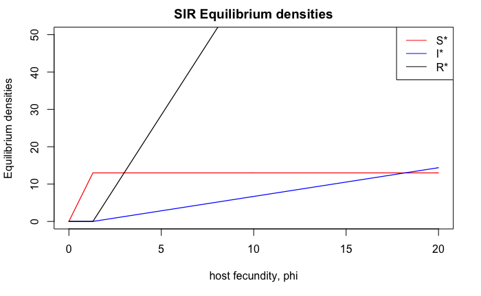

```r
lines(phi_all,R_equilibrium, type="l", col="black", lwd=1.25)
legend("topright", c("S*", "I*", "R*"), col=c("red", "blue", "black"), lty=1)
```

### Exercise 4: Explore how disease induced mortality affects the equilibrium.

> 1. Modify the code to make a plot of $S^*$, $I^*$, and $R^*$ as a function of $\alpha$. In this case, calculate the equilibrium values numerically.
> 2. As shown above, you can also calculate the equilibrium values analytically. Plot the analytical values to show that they give the same results.

```r
# HIDE ME IF YOU DON'T WANT TO SEE THE ANSWER
alpha_all<-seq(0,1,0.1)     # use a sequence of values for alpha
# set up a vector to store host equilibrium values
S_equilibrium<-rep(0,length(alpha_all))
I_equilibrium<-rep(0,length(alpha_all))
R_equilibrium<-rep(0,length(alpha_all))
    #specify the starting guesses for the state variables
x<-c(S=5,I=5,R=10)

for (i in 1:length(alpha_all)) {  # loop through all values of phi

    #specify the values of the parameters
    parameters <- c(beta = 0.1, gamma = 1, phi = 10, mu = 0.1, alpha = alpha_all[i])

    #call multiroot
    eqm<-multiroot(RHS_SIR, x, parms = parameters)

    S_equilibrium[i] = eqm$root[1]
    I_equilibrium[i] = eqm$root[2]
    R_equilibrium[i] = eqm$root[3]
}
S_analytical = (gamma + mu + alpha_all)/beta
I_analytical = (phi - mu *S_analytical)/(beta * S_analytical)
R_analytical = (gamma * I_analytical)/mu
plot(alpha_all,S_equilibrium, type="l", col="red", ylab="Equilibrium densities", xlab="host fecundity, phi", main="SIR Equilibrium densities", ylim=c(0, 100), lwd=1.25)
lines(alpha_all,I_equilibrium, type="l", col="blue", lwd=1.25)
```

```r
lines(alpha_all,R_equilibrium, type="l", col="black", lwd=1.25)
points(alpha_all,S_analytical, col="red")
```

```r
points(alpha_all,I_analytical, col="blue")
points(alpha_all,R_analytical, col="black")
```

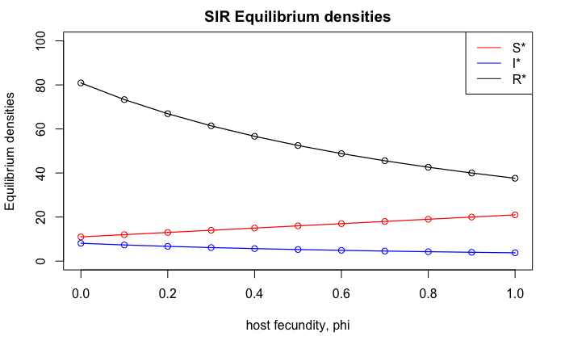

```r
legend("topright", c("S*", "I*", "R*"), col=c("red", "blue", "black"), lty=1)
```